# General Social Survey

Year 2019

# 1 Introduction Question 1

This data is from the 2018 General Social Survey. The first blocks of R-code has selected down a subset of the data to just 15 variables. It has further removed unwanted factor levels in much of the data. Examine that code to see what it is doing. Finally address this question. Is opinion on the death penalty (CAPPUN) independent of gun ownership (OWNGUN)?

## 1.1 Methods

The methods that I used for this variable analysis is a graphical analysis and a numerical analysis.

## 1.2 Results

### 1.2.1 Descriptive Results

#### 1.2.1.1 Graphical Descriptive Results

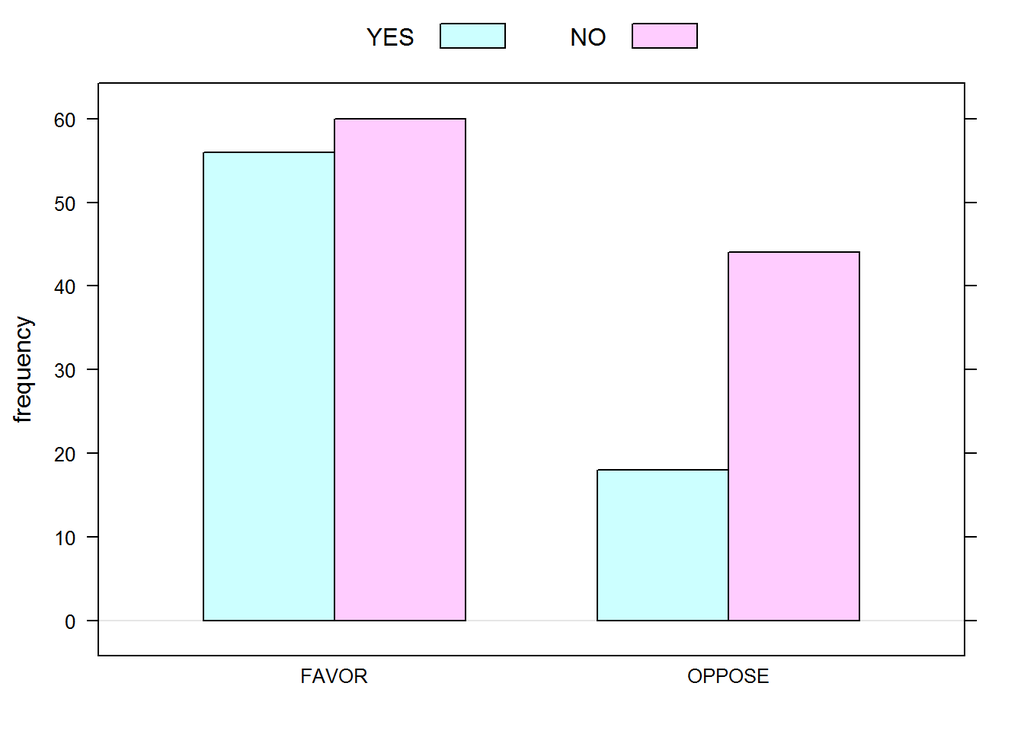

```r
barchartGC (~CAPPUN + OWNGUN,data=mydata4)
```

#### Numerical Descriptive Results

```r
table1 <- xtabs(~CAPPUN + OWNGUN, data=mydata4)
rowPerc(table1)
```

```
##         OWNGUN
## CAPPUN      YES     NO  Total
##   FAVOR   48.28  51.72 100.00
##   OPPOSE  29.03  70.97 100.00
```

```r
colPerc(table1)
```

```
##         OWNGUN
## CAPPUN      YES     NO
##   FAVOR   75.68  57.69
##   OPPOSE  24.32  42.31
##   Total  100.00 100.00
```

### 1.2.2 Inferential Results

```r
chisq.test(table1)
```

```
##
##  Pearson's Chi-squared test with Yates' continuity correction
##
## data:  table1
## X-squared = 5.3932, df = 1, p-value = 0.02022
```

```r
chisqtestGC(table1)
```

```
## Pearson's Chi-squared test with Yates' continuity correction
##
## Observed Counts:
##         OWNGUN
## CAPPUN   YES NO
##   FAVOR   56 60
##   OPPOSE  18 44
##
## Counts Expected by Null:
##         OWNGUN
## CAPPUN     YES    NO
##   FAVOR  48.22 67.78
##   OPPOSE 25.78 36.22
##
## Contributions to the chi-square statistic:
##         OWNGUN
## CAPPUN    YES   NO
##   FAVOR  1.25 0.89
##   OPPOSE 2.35 1.67
##
##
## Chi-Square Statistic = 5.3932
## Degrees of Freedom of the table = 1
## P-Value = 0.0202
```

```r
fisher.test(table1)
```

```
##
##  Fisher's Exact Test for Count Data
##
## data:  table1
## p-value = 0.01651
## alternative hypothesis: true odds ratio is not equal to 1
## 95 percent confidence interval:
##  1.130437 4.695225
## sample estimates:
## odds ratio
##      2.271
```

# 2 Introduction Question 2

Now answer Is belief in the bigbang theory (BIGBANG) independent of belief in the afterlife (POSTLIFE)

## 2.1 Methods

## 2.2 Results

### 2.2.1 Descriptive Results

#### 2.2.1.1 Graphical Descriptive Results

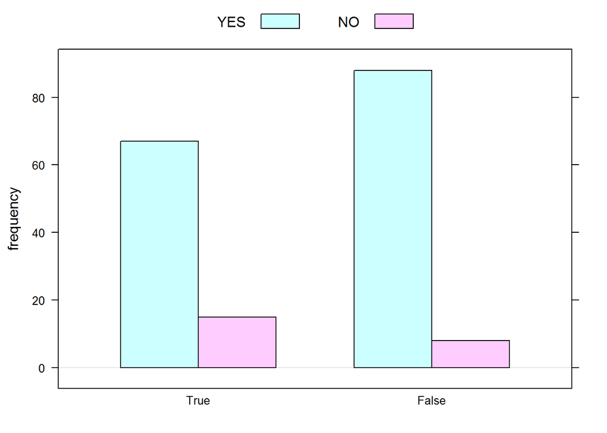

```r
barchartGC (~BIGBANG + POSTLIFE,data=mydata4)
```

#### Numerical Descriptive Results

```r
table2 <- xtabs (~BIGBANG + POSTLIFE, data=mydata4)
rowPerc(table2)
```

```
##        POSTLIFE
## BIGBANG    YES     NO  Total
##   True   81.71  18.29 100.00
##   False  91.67   8.33 100.00
```

```r
colPerc(table2)
```

```
##        POSTLIFE
## BIGBANG    YES     NO
##   True   43.23  65.22
##   False  56.77  34.78
##   Total 100.00 100.00
```

### 2.2.2 Inferential Results

```r
chisq.test(table2)
```

```
##
##  Pearson's Chi-squared test with Yates' continuity correction
##
## data:  table2
## X-squared = 3.0637, df = 1, p-value = 0.08006
```

```r
chisqtestGC(table2)
```

```
## Pearson's Chi-squared test with Yates' continuity correction
##
## Observed Counts:
##        POSTLIFE
## BIGBANG YES NO
##   True   67 15
##   False  88  8
##
## Counts Expected by Null:
##        POSTLIFE
## BIGBANG  YES   NO
##   True  71.4 10.6
##   False 83.6 12.4
##
## Contributions to the chi-square statistic:
##        POSTLIFE
## BIGBANG  YES   NO
##   True  0.27 1.83
##   False 0.23 1.56
##
##
## Chi-Square Statistic = 3.0637
## Degrees of Freedom of the table = 1
## P-Value = 0.0801
```

```r
fisher.test(table2)
```

```
##
##  Fisher's Exact Test for Count Data
##
## data:  table2
## p-value = 0.07143
## alternative hypothesis: true odds ratio is not equal to 1
## 95 percent confidence interval:
##  0.1410591 1.0968350
## sample estimates:
## odds ratio
##  0.4081275
```